# Logistic Regression

Preclinical and Clinical Data Analysis in Predictive Drug Discovery

2020-12-09

# Background

## Odds and probabilities

If the probability of an event $A$ is $p$, the odds of the event are
$$odds=\dfrac{p}{1 - p}.$$

Given the odds of an event $A$, the probability of the event is
$$p=\dfrac{\text{odds}}{1 + \text{odds}}.$$

## Simple logistic regression

Suppose that $Y$ is a binary response variable and $X$ is a predictor variable, where $Y = 1$ represents the particular outcome of interest.

The model for a single variable logistic regression, where $p(x) = P(Y = 1 | X = x)$, is
$$\text{log} \left[ \dfrac{p(x)}{1 - p(x)} \right] = \beta_0 + \beta_1 x.$$

The estimated model equation has the form
$$\text{log} \left[ \dfrac{\hat{p}(x)}{1 - \hat{p}(x)} \right] = b_0 + b_1 x,$$
where $b_0$ and $b_1$ are estimates of the model parameters $\beta_0$ and $\beta_1$.

## Multiple logistic regression

The principles of simple logistic regression can be extended to a multiple logistic regression model with several predictors. Suppose that $Y$ is a binary response variable, where $Y = 1$ represents the particular outcome of interest, and $X_1, X_2, \dots, X_p$ are predictor variables.

The model for multiple logistic regression, where $p(x) = P(Y = 1|x_1, x_2, ..., x_p)$, is
$$\log \left[\dfrac{p(x)}{1-p(x)} \right] = \beta_0 + \beta_1 x_2 + \beta_2 x_2 + \cdots + \beta_p x_p.$$

The estimated model equation has the form
$$\text{log} \left[ \dfrac{\hat{p}(x)}{1 - \hat{p}(x)} \right] = b_0 + b_1 x_1 + b_2 x_2 + \cdots + b_p x_p,$$
where $b_0, b_1, b_2, \dots, b_p$ are estimates of the model parameters $\beta_0, \beta_1, \beta_2, \dots, \beta_p$.

The coefficient $b_j$ of a predictor $x_j$ is the predicted change in the log of the estimated odds corresponding to a one unit change in $x_j$, when the values of all other predictors remain constant.

## Dataset

Patients admitted to an intensive care unit (ICU) are either extremely ill or considered to be at great risk of serious complications. There are no widely accepted criteria for distinguishing between patients who should be admitted to an ICU and those for whom admission to other hospital units would be more appropriate. Thus, among different ICUs, there are wide ranges in a patient’s chance of survival. When studies are done to compare effectiveness of ICU care, it is critical to have a reliable means of assessing the comparability of the different patient populations.

One such strategy for doing so involves the use of statistical modeling to relate empirical data for many patient variables to outcomes of interest. The following dataset consists of a sample of 200 subjects who were part of a much larger study on survival of patients following admission to an adult ICU.<sup>1</sup> The major goal of the study was to develop a logistic regression model to predict the probability of survival to hospital discharge.<sup>2</sup>

The following table provides a list of the variables in the dataset and their description. The data are accessible as the *icu* dataset in the *aplore3* package.

| Variable | Description |
| --- | --- |
| id | patient ID number |
| sta | patient status at discharge, either *Lived* or *Died* |
| age | age in years (when admitted) |
| gender | gender, either *Male* or *Female* |
| can | cancer part of current issue, either *No* or *Yes* |
| crn | history of chronic renal failure, either *No* or *Yes* |
| inf | infection probable at admission, either *No* or *Yes* |
| cpr | CPR prior to admission, either *No* or *Yes* |
| sys | systolic blood pressure at admission, in mm Hg |
| hra | heart rate at admission, in beats per minute |
| pre | previous admission to an ICU within 6 months, either *No* or *Yes* |
| type | type of admission, either *Elective* or *Emergency* |
| fra | long bone, multiple, neck, single area, or hip fracture, either *No* or *Yes* |
| po2 | $PO_2$ from initial blood gases, either *60* or *<=60*, in mm Hg |
| ph | $pH$ from initial blood gases, either *>= 7.25* or *< 7.25* |
| pco | $PCO_2$ from initial blood gases, either *<= 45* or *>45*, in mm Hg |
| bic | $HCO_3$ (bicarbonate) from initial blood gases, either *>= 18* or *<18*, in mm Hg |
| cre | creatinine from initial blood gases, either *<= 2.0* or *> 2.0*, in mg/dL |
| loc | level of consciousness at admission, either *Nothing*, *Stupor*, or *Coma* |

**References**

1. Hosmer, D. W., S. Lemeshow, and R. X. Sturdivant. Applied Logistic Regression: Third Edition. 2013.doi:10.1002/9781118548387

2. Lemeshow, S., D. Teres, J. S. Avrunin, and H. Pastides. Predicting the outcome of intensive care unit patients. *Journal of the American Statistical Association*, 1988.doi:10.1080/01621459.1988.10478604

# Questions

## Odds and probabilities

1. Create a two-way table of survival to discharge by whether CPR was administered prior to admission.
- Use the following code

  ```r
  #install the package (only needs to be done once)
  if(!nzchar(system.file(package = "aplore3"))) install.packages("aplore3")

  #load the data
  library(aplore3)
  data("icu")

  #relevel survival so that 1 corresponds to surviving to discharge
  icu$sta = factor(icu$sta, levels = rev(levels(icu$sta)))

  #create two-way table
  addmargins(table(icu$sta, icu$cpr,
               dnn = c("Survival", "Prior CPR")))
  ```

  ```
  ##         Prior CPR
  ## Survival  No Yes Sum
  ##    Died   33   7  40
  ##    Lived 154   6 160
  ##    Sum   187  13 200
  ```

- Calculate the odds and probability of survival to discharge for those who did not receive CPR prior to ICU admission. Is someone who did not receive CPR prior to admission more likely to survive to discharge than to not survive to discharge?
- Calculate the odds and probability of survival to discharge for those who received CPR prior to ICU admission. Is someone who received CPR prior to admission more likely to survive to discharge than not?
- Calculate the odds ratio (OR) of survival to discharge, comparing patients who receive CPR prior to admission to those who do not receive CPR prior to admission. Calculate also the relative risk (RR) of the same (The RR or risk ratio is the ratio of the probability of an outcome in an exposed group to the probability of an outcome in an unexposed group).

*Solution*.

**Question 2**

The odds of survival to discharge for those who did not receive CPR prior to ICU admission are 4.67, which corresponds to a probability of 0.82. Someone who does not receive CPR prior to admission is more likely to survive to discharge than die before discharge. An odds greater than 1 corresponds to probability greater than 50%.

```r
#calculate odds
odds_no_cpr = 154/33
odds_no_cpr
```

```
## [1] 4.666667
```

```r
#convert to probability
p_no_cpr = (odds_no_cpr)/(1 + odds_no_cpr)
p_no_cpr
```

```
## [1] 0.8235294
```

**Question 3**

The odds of survival to discharge for those who receive CPR prior to ICU admission are 0.857, which corresponds to a probability of 0.46. Someone who receives CPR prior to admission is less likely to survive to discharge than survive to discharge. An odds less than 1 corresponds to probability less than 50%.

```r
#calculate odds
odds_cpr = 6/7
odds_cpr
```

```
## [1] 0.8571429
```

```r
#convert to probability
p_cpr = (odds_cpr)/(1 + odds_cpr)
p_cpr
```

```
## [1] 0.4615385
```

**Question 4**

The odds ratio of survival to discharge, comparing patients who receive CPR prior to admission to those who do not receive CPR prior to admission is

```r
(or_cpr <- odds_cpr/odds_no_cpr)
```

```
## [1] 0.1836735
```

The RR is

```r
(rr_cpr <- p_cpr/p_no_cpr)
```

```
## [1] 0.5604396
```

## Simple logistic regression

1. Survival vs. CPR: Fit a logistic regression model to predict survival to discharge from prior CPR.
- use the following code

  ```r
  glm_cpr_fit <- glm(sta ~ cpr, data = icu,
                 family = binomial(link = "logit"))
  summary(glm_cpr_fit)
  ```

  ```
  ##
  ## Call:
  ## glm(formula = sta ~ cpr, family = binomial(link = "logit"), data = icu)
  ##
  ## Deviance Residuals:
  ##     Min       1Q   Median       3Q      Max
  ## -1.8626   0.6231   0.6231   0.6231   1.2435
  ##
  ## Coefficients:
  ##             Estimate Std. Error z value Pr(>|z|)
  ## (Intercept)   1.5404     0.1918   8.031 9.71e-16 ***
  ## cprYes       -1.6946     0.5885  -2.880  0.00398 **
  ## ---
  ## Signif. codes:  0 '***' 0.001 '**' 0.01 '*' 0.05 '.' 0.1 ' ' 1
  ##
  ## (Dispersion parameter for binomial family taken to be 1)
  ##
  ##     Null deviance: 200.16  on 199  degrees of freedom
  ## Residual deviance: 192.23  on 198  degrees of freedom
  ## AIC: 196.23
  ##
  ## Number of Fisher Scoring iterations: 4
  ```

- Write the model equation estimated from the data.
- Plot the model fit using the code below and interpret.

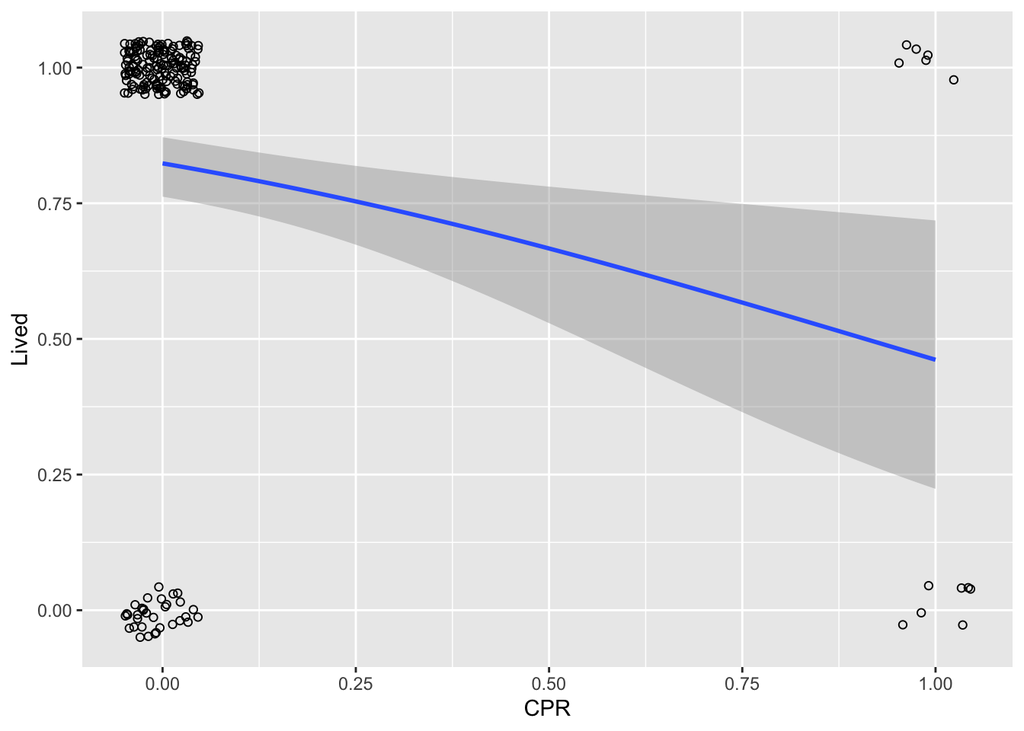

  ```r
  library(ggplot2)
  library(tidyverse)
  icu %>% mutate(Lived = ifelse(sta == "Lived", 1, 0)) %>%
    mutate(CPR = ifelse(cpr == "Yes", 1, 0)) %>%
    ggplot(aes(x=CPR, y=Lived)) +
    geom_point(shape=1,
           position=position_jitter(width=.05,height=.05)) +
    stat_smooth(method="glm",
            method.args=list(family="binomial"),
            se=TRUE)
  ```

- Interpret the intercept. Confirm that the interpretation coheres with the first answer in the Odds and probabilities section.
- compute the probability of survival to discharge for those who did and did not receive CPR prior to ICU admission. Are they the same as those calculated in the Odds and probabilities section?

  ```r
  predict(glm_cpr_fit, data.frame(cpr=c("No")), type="response")
  ```

  ```
  ##         1
  ## 0.8235294
  ```

  ```r
  predict(glm_cpr_fit, data.frame(cpr=c("Yes")), type="response")
  ```

  ```
  ##         1
  ## 0.4615385
  ```

- Interpret the slope coefficient. Compute the exponential of the slope coefficient and confirm that this matches the OR computed in the Odds and probabilities section.
- Is there evidence of a statistically significant association between survival to discharge and prior CPR at $\alpha = 0.05$?

*Solution*.

**Question 2**

$$\log\left[\frac{\hat{p}( \text{status = lived} |\text{cpr})}{1 - \hat{p}(\text{status = lived} | \text{cpr})}\right] = 1.540 -1.695(cpr_{yes})$$

$$\log (\widehat{\text{odds}}\text{ of lived | cpr}) = 1.540 -1.695(cpr_{yes})$$

**Question 4**

The intercept represents the log of the estimated odds of survival to discharge for individuals who did not receive CPR prior to ICU admission; thus, the estimated odds of survival for this group are $\exp(1.540) = 4.67$.

**Question 5**

```r
(p_no_cpr_est <- predict(glm_cpr_fit, data.frame(cpr=c("No")), type="response"))
```

```
##         1
## 0.8235294
```

```r
p_no_cpr  # observed value
```

```
## [1] 0.8235294
```

```r
(p_cpr_est <- predict(glm_cpr_fit, data.frame(cpr=c("Yes")), type="response"))
```

```
##         1
## 0.4615385
```

```r
p_cpr  # observed value
```

```
## [1] 0.4615385
```

They are the same.

**Question 6**

The slope coefficient represents the change in the log of the estimated odds of survival to discharge from the no CPR group to the CPR group; $\exp(-1.695) = 0.184$, which represnts the estimated odds ratio for survival to discharge, comparing those who received CPR prior to admission to those who did not.

**Question 7**

Yes, the $p$-value is 0.004, which is less than $\alpha = 0.05$. There is sufficient evidence to reject $H_0: \beta_1 = 0$ in favor of the alternative. There is evidence of an association between receiving CPR prior to ICU admission and lower probability of survival to discharge.

1. Survival vs. Creatinine level: Creatinine level in the data are recorded as being either less than or equal to 2.0 mg/dL or greater than 2.0 mg/dL. A typical creatinine level is between 0.5 - 1.0 mg/dL, and elevated creatinine may be a sign of renal failure. Fit a logistic regression model to predict survival to discharge from an indicator of elevated creatinine.
- use the following code

  ```r
  glm_cre_fit <- glm(sta ~ cre, data = icu,
                 family = binomial(link = "logit"))
  summary(glm_cre_fit)
  ```

  ```
  ##
  ## Call:
  ## glm(formula = sta ~ cre, family = binomial(link = "logit"), data = icu)
  ##
  ## Deviance Residuals:
  ##     Min       1Q   Median       3Q      Max
  ## -1.8394   0.6381   0.6381   0.6381   1.1774
  ##
  ## Coefficients:
  ##             Estimate Std. Error z value Pr(>|z|)
  ## (Intercept)   1.4881     0.1871   7.951 1.84e-15 ***
  ## cre> 2.0     -1.4881     0.6596  -2.256   0.0241 *
  ## ---
  ## Signif. codes:  0 '***' 0.001 '**' 0.01 '*' 0.05 '.' 0.1 ' ' 1
  ##
  ## (Dispersion parameter for binomial family taken to be 1)
  ##
  ##     Null deviance: 200.16  on 199  degrees of freedom
  ## Residual deviance: 195.40  on 198  degrees of freedom
  ## AIC: 199.4
  ##
  ## Number of Fisher Scoring iterations: 4
  ```

- plot the model fit and interpret.
- Is there evidence of a statistically significant association between survival to discharge and an indicator of elevated creatinine at $\alpha = 0.05$?

*Solution*.

**Question 2**

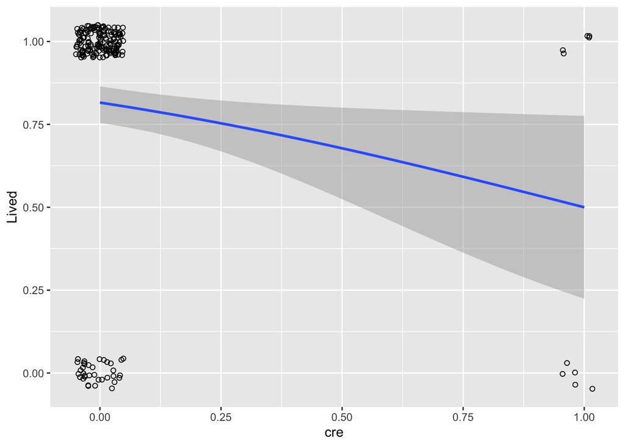

```r
icu %>% mutate(Lived = ifelse(sta == "Lived", 1, 0)) %>%
  mutate(cre = ifelse(cre == "<= 2.0", 0, 1)) %>%
  ggplot(aes(x=cre, y=Lived)) +
  geom_point(shape=1,
             position=position_jitter(width=.05,height=.05)) +
  stat_smooth(method="glm",
              method.args=list(family="binomial"),
              se=TRUE)
```

Lots of uncertainty but there is a trend.

1. Survival vs. age: Fit a logistic regression model to predict survival to discharge from age.
- use the following code

  ```r
  glm_age_fit <- glm(sta ~ age, data = icu,
                 family = binomial(link = "logit"))
  summary(glm_age_fit)
  ```

  ```
  ##
  ## Call:
  ## glm(formula = sta ~ age, family = binomial(link = "logit"), data = icu)
  ##
  ## Deviance Residuals:
  ##     Min       1Q   Median       3Q      Max
  ## -2.2854   0.3905   0.6145   0.7391   0.9536
  ##
  ## Coefficients:
  ##             Estimate Std. Error z value Pr(>|z|)
  ## (Intercept)  3.05851    0.69608   4.394 1.11e-05 ***
  ## age         -0.02754    0.01056  -2.607  0.00913 **
  ## ---
  ## Signif. codes:  0 '***' 0.001 '**' 0.01 '*' 0.05 '.' 0.1 ' ' 1
  ##
  ## (Dispersion parameter for binomial family taken to be 1)
  ##
  ##     Null deviance: 200.16  on 199  degrees of freedom
  ## Residual deviance: 192.31  on 198  degrees of freedom
  ## AIC: 196.31
  ##
  ## Number of Fisher Scoring iterations: 4
  ```

- plot the model fit and interpret.

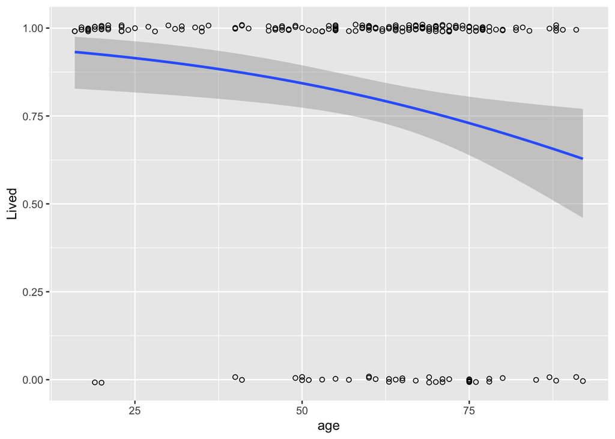

  ```r
  library(ggplot2)
  library(tidyverse)
  icu %>% mutate(Lived = ifelse(sta == "Lived", 1, 0)) %>%
    ggplot(aes(x=age, y=Lived)) +
    geom_point(shape=1,
           position=position_jitter(width=0,height=.01)
           ) +
    stat_smooth(method="glm",
            method.args=list(family="binomial"),
            se=TRUE)
  ```

- Does the intercept have a meaningful interpretation in the context of the data?
- Interpret the slope coefficient.
- Calculate the probability of survival to discharge for a 70-year-old individual. Is a 70-year-old individual more likely to survive than not?

  ```r
  predict(glm_age_fit, data.frame(age=70), type="response")
  ```

  ```
  ##         1
  ## 0.7559368
  ```

- Calculate the odds ratio and relative risk of survival to discharge comparing a 45-year-old individual to a 70-year-old individual.

*Solution*.

**Question 2**

There is a trend here as well.

**Question 3**

The intercept represents the log odds of survival to discharge for an individual of age 0 years admitted to the ICU. Since the youngest age observed in the dataset is 16 years, the intercept does not represent a reliable estimate of the odds of survival to discharge for a newborn who needs intensive care.

**Question 4**

**Question 5**

```r
predict(glm_age_fit, data.frame(age=70), type="response")
```

```
##         1
## 0.7559368
```

**Question 6**

The odds ratio can be calculated directly from the model slope, or from calculating the odds at each age then dividing to obtain the ratio. The odds ratio of survival to discharge comparing a 45-year-old individual to a 70-year-old individual is $e^{(70-45)(0.02754)} = 1.99$; the odds of survival to discharge are almost twice as large for a 45-year-old than a 70-year-old.

## Multiple logistic regression

1. Three predictors: Fit a single model to predict survival to discharge (sta) from age (age), CPR prior to admission (cpr), and an indicator of elevated creatinine level (cre).
- use the following code:

  ```r
  glm_multi_fit_1 <- glm(sta ~ age + cpr + cre, data = icu,
                 family = binomial(link = "logit"))
  summary(glm_multi_fit_1)
  ```

  ```
  ##
  ## Call:
  ## glm(formula = sta ~ age + cpr + cre, family = binomial(link = "logit"),
  ##     data = icu)
  ##
  ## Deviance Residuals:
  ##     Min       1Q   Median       3Q      Max
  ## -2.3890   0.3446   0.5580   0.6784   1.2868
  ##
  ## Coefficients:
  ##             Estimate Std. Error z value Pr(>|z|)
  ## (Intercept)  3.32901    0.74884   4.446 8.77e-06 ***
  ## age         -0.02814    0.01125  -2.502  0.01235 *
  ## cprYes      -1.69680    0.62145  -2.730  0.00633 **
  ## cre> 2.0    -1.13328    0.70191  -1.615  0.10641
  ## ---
  ## Signif. codes:  0 '***' 0.001 '**' 0.01 '*' 0.05 '.' 0.1 ' ' 1
  ##
  ## (Dispersion parameter for binomial family taken to be 1)
  ##
  ##     Null deviance: 200.16  on 199  degrees of freedom
  ## Residual deviance: 181.47  on 196  degrees of freedom
  ## AIC: 189.47
  ##
  ## Number of Fisher Scoring iterations: 5
  ```

- Write the model equation.
- Identify the significant predictors of survival to discharge from this model.
- Interpret the slope coefficients.
- Compare the odds of survival for those who did receive CPR prior to admission to those who did not receive CPR prior to admission.
- Using `predict()`, calculate the probability of survival for a 65-year-old individual who did not receive CPR prior to admission and had creatinine level of 1.1 mg/dL. Is this individual more likely to survive than not survive?

*Solution*.

**Question 2**

$$\log\left[\frac{\hat{p}( \text{status = lived} |\text{age, cpr, cre})}{1 - \hat{p}(\text{status = lived} | \text{age, cpr, cre})}\right] = 3.329 -0.0281(age) -1.697(cpr_{yes} -1.133(cre_{> 2.0})$$

$$\log(\widehat{\text{odds}}\text{ of lived | age, cpr, creatinine}) = 3.329 -0.0281(age) -1.697(cpr_{yes} -1.133(cre_{> 2.0})$$

**Question 3**

The significant predictors of survival to discharge are age and prior CPR; each have $p$-value lower than 0.05.}

```r
summary(glm_multi_fit_1)$coef
```

```
##                Estimate Std. Error   z value     Pr(>|z|)
## (Intercept)  3.32900649 0.74883543  4.445578 8.765577e-06
## age         -0.02814438 0.01124839 -2.502082 1.234655e-02
## cprYes      -1.69680316 0.62144856 -2.730400 6.325752e-03
## cre> 2.0    -1.13327763 0.70191415 -1.614553 1.064075e-01
```

**Question 4**

The slope coefficient for age indicates that an increase in 1 year of age is associated with a decrease of 0.0281 in the estimated log odds of survival to discharge, when the values of the other variables do not change.

The slope coefficient for prior CPR indicates that the estimated log odds of survival to discharge are 1.697 lower in individuals who receive CPR prior to admission (versus not receiving CPR), when the values of the other variables do not change.

The slope coefficient for creatinine indicates that the estimated log odds of survival to discharge are 1.133 lower in individuals with creatinine higher than 2.0 mg/dL (versus lower than or equal to), when the values of the other variables do not change.

**Question 5**

The odds ratio, comparing those who did receive CPR to those who did not, can be directly calculated from the slope coefficient: $\exp(-1.697) = 0.183$. It can be easier to interpret the reciprocal, $\exp(1.697) = 5.46$. The odds of survival to discharge for those who do not receive CPR prior to admission are almost 6 times as large as those for patients who do receive CPR prior to ICU admission. This is larger than seen in the model with only CPR as a predictor.

**Question 6**

The probability is

```r
predict(glm_multi_fit_1, data.frame(age=65,cpr="No",cre="<= 2.0"), type="response")
```

```
##         1
## 0.8175181
```

This is more than 50% so the patient has more chance to live than to die.

2. Two predictors with interaction: Fit a model for predicting survival to discharge from age, CPR prior to admission, and the interaction between age and CPR prior to admission.
- use the folowing code:

  ```r
  #fit a model
  glm_multi_fit_2 <- glm(sta ~ age*cpr, data = icu,
                         family = binomial(link = "logit"))
  summary(glm_multi_fit_2)
  ```

  ```
  ##
  ## Call:
  ## glm(formula = sta ~ age * cpr, family = binomial(link = "logit"),
  ##     data = icu)
  ##
  ## Deviance Residuals:
  ##     Min       1Q   Median       3Q      Max
  ## -2.3000   0.3792   0.5847   0.6860   1.7130
  ##
  ## Coefficients:
  ##             Estimate Std. Error z value Pr(>|z|)
  ## (Intercept)  3.04196    0.73569   4.135 3.55e-05 ***
  ## age         -0.02477    0.01117  -2.218   0.0266 *
  ## cprYes       3.72294    4.21464   0.883   0.3771
  ## age:cprYes  -0.09419    0.07080  -1.330   0.1834
  ## ---
  ## Signif. codes:  0 '***' 0.001 '**' 0.01 '*' 0.05 '.' 0.1 ' ' 1
  ##
  ## (Dispersion parameter for binomial family taken to be 1)
  ##
  ##     Null deviance: 200.16  on 199  degrees of freedom
  ## Residual deviance: 181.11  on 196  degrees of freedom
  ## AIC: 189.11
  ##
  ## Number of Fisher Scoring iterations: 5
  ```

- Interpret the slope of the interaction term.
- Assess whether this model is a more parsimonious model than the “three predictors” model.
- Using `predict()`, calculate the probability of survival for a 65-year-old individual who did not receive CPR prior to admission and had creatinine level of 1.1 mg/dL. How does this prediction compare to the previous model?

*Solution*.

**Question 2**

The slope of the interaction term indicates the association between estimated log odds of survival to discharge and age is more negative for individuals who received CPR prior to admission compared to those who did not receive CPR prior to admission. In other words, an increase in age is associated with a greater decrease in log odds of survival for patients who received CPR. The slope coefficient for age is -0.0248 in the group who did not receive prior CPR, and $-0.0248 - 0.0942 = -0.119$ in the group who received prior CPR.

**Question 3**

The AIC of this model is 189.1, while the AIC of the earlier model is 189.5. By only a very slim margin, AIC indicates that this model is a better parsimonious model.

```r
AIC(glm_multi_fit_1,glm_multi_fit_2)
```

```
##                 df      AIC
## glm_multi_fit_1  4 189.4655
## glm_multi_fit_2  4 189.1097
```

**Question 4**

The probability is

```r
predict(glm_multi_fit_2, data.frame(age=65,cpr="No",cre="<= 2.0"), type="response")
```

```
##         1
## 0.8072334
```

**Question 5**

**Question 6**

The probability is

```r
predict(glm_multi_fit_2, data.frame(age=65,cpr="No",cre="<= 2.0"), type="response")
```

```
##         1
## 0.8072334
```

Compared to the previous model

```r
predict(glm_multi_fit_1, data.frame(age=65,cpr="No",cre="<= 2.0"), type="response")
```

```
##         1
## 0.8175181
```

No a big difference really.